# What’s Cooking?

Arthur Sena

September 18, 2016

# Analisando nossos dados

Antes de qualquer coisa, precisamos saber com que tipo de dados nós estamos lidando aqui. No caso, temos um arquivo ‘json’ de 12MB contendo uma lista com a descrição de 39774 pratos de comidas. Para cada um desses pratos de comidas temos uma lista de ingredientes e um determinado ID. Abaixo é possível visualizar uma porção dos nossos dados.

```r
  train <- fromJSON("/home/arthur/Documents/redes_neurais/cuisine/train.json")
  head(train)
```

```
##      id     cuisine
## 1 10259       greek
## 2 25693 southern_us
## 3 20130    filipino
## 4 22213      indian
## 5 13162      indian
## 6  6602    jamaican
##                                                                                                                                                                                                                                        ingredients
## 1                                                                                                                     romaine lettuce, black olives, grape tomatoes, garlic, pepper, purple onion, seasoning, garbanzo beans, feta cheese crumbles
## 2                                                                                                              plain flour, ground pepper, salt, tomatoes, ground black pepper, thyme, eggs, green tomatoes, yellow corn meal, milk, vegetable oil
## 3                                                                                               eggs, pepper, salt, mayonaise, cooking oil, green chilies, grilled chicken breasts, garlic powder, yellow onion, soy sauce, butter, chicken livers
## 4                                                                                                                                                                                                                water, vegetable oil, wheat, salt
## 5 black pepper, shallots, cornflour, cayenne pepper, onions, garlic paste, milk, butter, salt, lemon juice, water, chili powder, passata, oil, ground cumin, boneless chicken skinless thigh, garam masala, double cream, natural yogurt, bay leaf
## 6                                                                                                  plain flour, sugar, butter, eggs, fresh ginger root, salt, ground cinnamon, milk, vanilla extract, ground ginger, powdered sugar, baking powder
```

Vamos agora analisar o quão bem distribuído se encontra nossos dados.

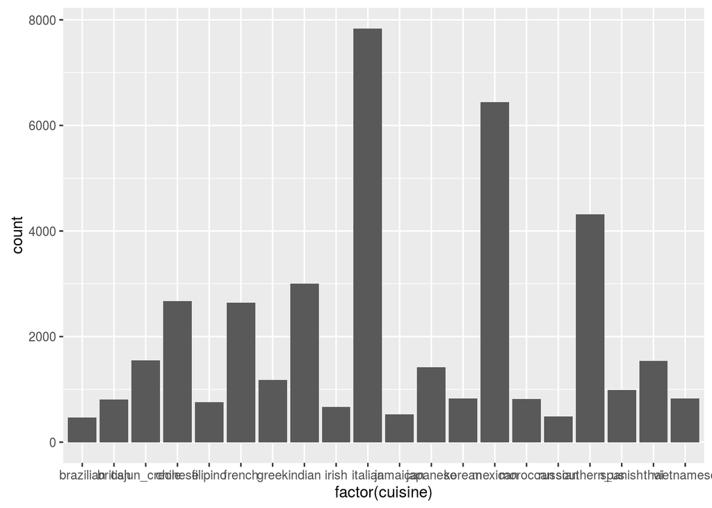

```r
  c <- ggplot(train, aes(factor(cuisine)))
  c + geom_bar()
```

Pelo gráfico acima, vemos que temos muitos pratos italianos e mexicanos nos nossos dados.

# Primeira Abordagem

Minha primeira idéia pra resolver tal problema é criar um ‘dataset’ que contenha ‘n’ colunas representando cada ingrediente encontrado no ‘dataset’ de treino e uma variável ‘target’ como rótulo. Contudo, essa idéia é inviável visto que eu tenho mais de 6 mil diferentes tipos de ingredientes, ou seja, precisaria de um ‘dataset’ com essa mesma quantidade de colunas :(

Uma simples abordagem pra tentar resolver esse problema é tentar filtrar essa quantidade de ingredientes e tentar trabalhar com os ingredientes que se encontram mais presentes nos nossos dados.

```r
brasil <-train[train$cuisine == 'brazilian',]
```

# teste

```r
ingred_freq_by_cuisine <- read.csv("~/Documents/redes_neurais/cuisine/ingred_freq_by_cuisine.csv", header=FALSE)
colnames(ingred_freq_by_cuisine) <- c("cuisine","ingredient","freq")
ingred_freq_by_cuisine$freq <- as.numeric(ingred_freq_by_cuisine$freq)
ingred_freq_by_cuisine<-ingred_freq_by_cuisine %>% arrange(cuisine,desc(freq))

length(unique(ingred_freq_by_cuisine$ingredient))
```

```
## [1] 6696
```

```r
ingred_freq_by_cuisine_20 <- read.csv("~/Documents/redes_neurais/cuisine/ingred_freq_by_cuisine_20.csv", header=FALSE)
colnames(ingred_freq_by_cuisine_20) <- c("cuisine","ingredient","freq")
length(unique(ingred_freq_by_cuisine_20$ingredient))
```

```
## [1] 1095
```

```r
ingred_freq_by_cuisine_100 <- read.csv("~/Documents/redes_neurais/cuisine/ingred_freq_by_cuisine_100.csv", header=FALSE)
colnames(ingred_freq_by_cuisine_100) <- c("cuisine","ingredient","freq")
length(unique(ingred_freq_by_cuisine_100$ingredient))
```

```
## [1] 348
```